# 因果推断简介之七：Lord’s Paradox

丁鹏

2013-09-09T19:00:58+00:00

`$$ \def\ind{{\perp\!\!\!\perp}} \def\nind{{\not\!\perp\!\!\!\perp}} $$`

# 一 Lord’s Paradox

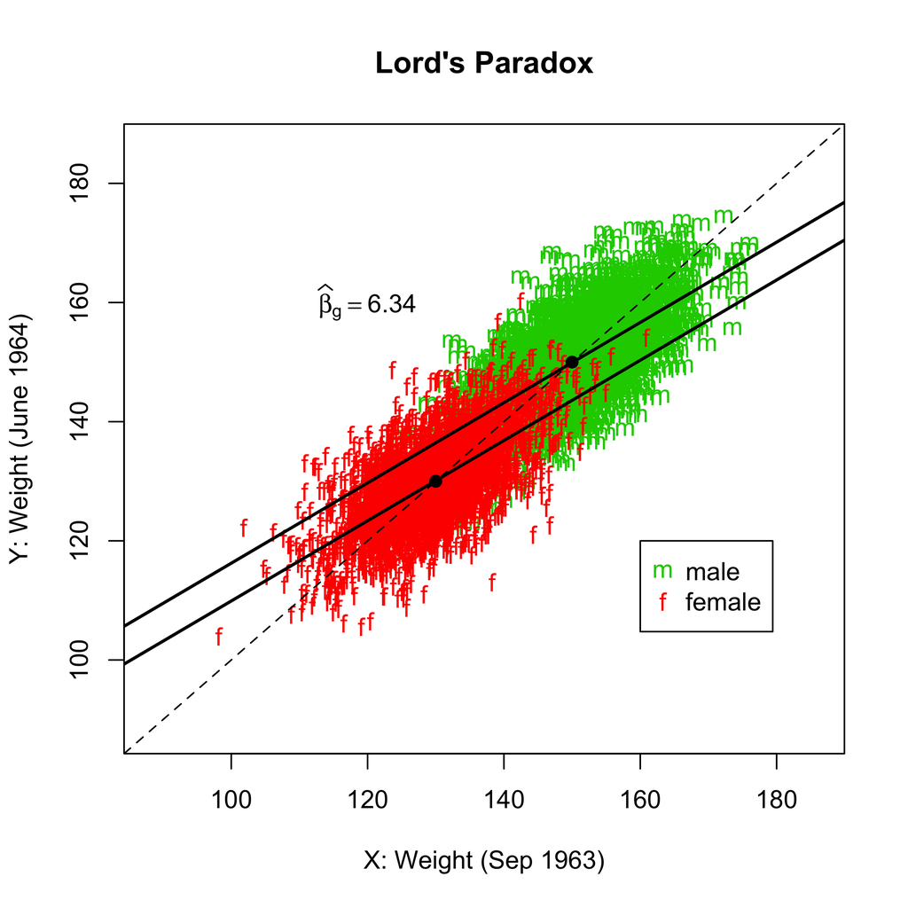

LordPlot

第二个统计学家，由于受到了高等的统计训练，知道 R A Fisher 的 Analysis of Covariance (ANCOVA) ，提出了更加复杂的方法。他认为，我们的分析应该控制入学前的体重，做如下的线性回归：

`$$ Y_i = \beta_0 + \beta_g G_i + \beta_x X_i + \varepsilon_i. \quad\quad\quad (*) $$`

他进一步认为，上面线性回归的系数`$\beta_g$`反应的就是男女的差别。用最小二乘法拟合上面的回归模型，等价于在男女学生中拟合两条平行的回归直线。如图所示，两条直线斜率`$\beta_x$`相同，但是截距不同，截距之差就是回归系数`$\widehat{\beta}_g = 6.34$`。结论是，食堂对于男女体重有差别性的影响。

这两位统计学家得到了不同的结论，究竟谁对谁错呢？Lord 称这个现象为悖论，那么悖论的根源是什么呢？

# 二 悖论的根源：因果推断视角下的解释

要想解释这个悖论，使用线性回归模型益处不大，因为究竟能否将回归系数解释成因果作用，是个根本性的问题。在下面的讨论中，我们假定数据的样本量足够大，因而可以忽略小样本带来的随机性；也可以认为整个讨论都在总体上进行。和前面一样，我们用`$G_i$`表示个体`$i$`的性别，男性取值为1， 女性取值为0；`$X_i$`是个体 `$i$`在 1963 年 9 月的体重。由于这两个变量都发生在接受处理（在食堂进餐与否）之前，它们都可以看成是协变量，不受处理的影响。我们采用潜在结果模型，定义 `$\{ Y_i(1), Y_i(0) \} $`是个体 $i$ 在食堂进餐和不在食堂进餐下于 1964 年六月体重的潜在结果。

如果用`$T$`表示在食堂进餐与否的变量，那么每个学生都是`$T=1$`。当写下潜在结果之后，我们就发现问题的根源之一，是整个研究根本不存在对照组（全体学生其实都在食堂进餐），每个个体在 1964 年 6 月都取值`$Y(1)$`(也就是前面的记号`$Y$`)。

继续我们的讨论。男女学生的平均因果作用分别定义为：

`$$ \Delta_g = E\{ Y(1) – Y(0) \mid G = g \}, g=1, 0; $$`

食堂对于男女学生体重平均因果作用的差是：

`$$ \begin{eqnarray} \Delta &=& \Delta_1 – \Delta_0\\ &=& E\{ Y(1) – Y(0) \mid G = 1 \} – E\{ Y(1) – Y(0) \mid G = 0 \}\\ &=& \left[ E\{ Y(1) \mid G = 1 \} – E\{ Y(1) \mid G = 0 \} \right] \\ && – \left[ E\{ Y(0) \mid G = 1 \} – E\{ Y(0) \mid G = 0 \} \right]. \end{eqnarray} $$`

上面的推导虽然简单，但是将`$\Delta$`分成了两个显著不同的部分：第一个方括号内的项是我们能够从观测数据中得到的；第二个方括号中的项是我们不可观测的，因为没有任何一个学生接受了食堂之外的处理。

如果我们假定`$Y(0) = X$`，也就是说如果学生不来食堂进餐，他们的体重将和入学前一样，那么

`$$ \Delta_g = E\{ Y(1) – X\mid G = g \} = E(Y-X\mid G=g). $$`

显然，假定`$Y(0) = X$`是无法被数据证明或者证伪的，它只能依赖于我们的先验知识。那么在什么假定下，第二个统计学家又是对的呢？

根据第二个统计学家做 ANCOVA 的逻辑，他可以假定

`$$ \begin{eqnarray} \Delta &=& E\{ Y(1) – Y(0) \mid G=1\} – E\{ Y(1) – Y(0)\mid G=0\} \\ &=& E\{ Y(1) – \alpha – bX \mid G=1\} – E\{ Y(1) – \alpha – bX\mid G=0\} \\ &=& \left[ E\{ Y(1) \mid G=1\} – b E(X\mid G=1) \right] \\ &&- \left[ E\{ Y(1)\mid G=0\} – b E(X\mid G=0) \right]\\ &=& a_1 – a_0 = \delta. \end{eqnarray} $$`

最后一行等于`$\delta$`，因为根据条件期望的性质，方括号中的两项分别是`$a_1$`和`$a_0$`：

`$$ \begin{eqnarray} && E\{ Y(1) \mid G=g\} – b E(X\mid G=g) \\ &=& E\left[ E\{ Y(1) \mid X, G=g\} \mid G=g\right] – b E(X\mid G=g) \\ &=& E\left[ a_g + bX \mid G=g\right] – b E(X\mid G=g) \\ &=& a_g. \end{eqnarray} $$`

这样一来，第二个统计学家的结论就是正确的。

# 三 结论

根据上面的讨论，关于 Lord’s Paradox，我们有如下的结论：

（1）Lord’s Paradox 的根源在于，整个研究没有对照组；我们甚至不知道什么是对照组，不在食堂进餐，是在家里进餐，还是外面的参观进餐，还是其他？这其实导致 $Y(0)$ 并非完好定义。上面的讨论则是假定`$Y(0)$`是良好定义的。

（2）回归或者协方差分析等统计工具，并不能清楚的回答因果的问题。这个问题中，`$\Delta$`是一个我们关心的因果度量，离开潜在结果，是很难定义的。根据上面的讨论，两位统计学家不采用潜在结果模型，甚至没有意识到，这个研究根本的问题在于缺少对照。当然，如果我们能够做一个随机化的实验，有处理和对照组，那么回归分析也可能得到合理的答案。

（3）统计学家一和二，都可以是对的。他们结论的正确性，依赖于不同的假定；而这些假定本身是不可能被检验的。

（4）假定`$Y(0)=X$`可以减弱到`$Y(0)=X+u, E(u)=0, u\ind G$`；假定`$Y(0)= \alpha + b X$`可以减弱到`$Y(0) = \alpha + bX + v, E(v) = 0, v\ind G$`。当然，这都是细枝末节的问题。

（5）统计学家一和二，都是错的。他们有结论，但是却从未清楚地陈述结论回答的是什么问题。

（6）R A Fisher 在实验设计中提出了 ANCOVA，但是这个方法不是万能的。事实上，这个方法导致的问题，比它带来的功用更严重；这点以后再说。

# 四 参考文献

（1）Lord FM. A paradox in the interpretation of group comparisons. Psychol Bull. 1967;68:304–5. doi: 10.1037/h0025105.

（2）Holland, P.W., Rubin, D.B. (1983). On Lord’s paradox. In: Wainer, H., Messick, S. (Eds.), Principals of Modern Psychological Measurement. Lawrence Erlbaum Associates, Hillsdale, NJ, pp. 3–25.